# IF540L_Kelas_EL_laporan_M07_00000060236_Nisaul Fadhilah

## TUGAS LAB IF540 MACHINE LEARNING

### WEEK 07 : Klasifikasi Bayes dan Support Vector

#### Semester Genap 2022/2023

```python
# Run this code when you restart the machine
# Fill in with YOUR name and NIM
import datetime
import uuid

myName = "Nisa'ul Fadhilah"
myNIM = "00000060236"
```

```python
myDate = datetime.datetime.now()
myDevice = str(uuid.uuid1())

print("Name: \t\t{}".format(myName))
print("NIM: \t\t{}".format(myNIM))
print("Start: \t\t{}".format(myDate))
print("Device ID: \t{}".format(myDevice))
```

```
Name: 		Nisa'ul Fadhilah
NIM: 		00000060236
Start: 		2023-10-19 09:01:07.840301
Device ID: 	5e336bc6-6e23-11ee-b4a6-2c3b70a37f3c
```

### Penjelasan Dataset:

dataset.csv: dataset ini digunakan untuk tujuan identifikasi bahasa. Setiap bahasa dalam dataset ini memiliki 1000 baris/paragraf yang digunakan untuk melatih dan menguji model identifikasi bahasa. Dataset ini dapat digunakan dalam berbagai tugas pemrosesan bahasa alami (Natural Language Processing, NLP) yang melibatkan identifikasi atau klasifikasi bahasa, seperti pengenalan bahasa dalam teks, penerjemahan otomatis, analisis sentimen, dan tugas NLP lainnya. Sedangkan mnist_test.csv bertujuan dari dataset ini adalah untuk digunakan dalam pengenalan digit tulisan tangan. Artinya, setiap contoh data terdiri dari gambar digit tulisan tangan dan label yang sesuai dengan digit tersebut. Dataset ini digunakan untuk melatih dan menguji model pembelajaran mesin untuk mengenali dan mengklasifikasikan digit tulisan tangan ke dalam kategori 0 hingga 9. Dataset MNIST sering digunakan sebagai dasar dalam memahami konsep dasar dalam pembelajaran mesin dan pengolahan gambar.

### Dataset yang dipakai:

1. dataset.csv – sumber : https://www.kaggle.com/datasets/zarajamshaid/language-identification-datasst
2. mnist_test.csv – sumber : https://www.kaggle.com/datasets/oddrationale/mnist-in-csv

### Hasil kerja

#### Importing system library

```python
import sys
```

#### Importing numpy library

```python
%matplotlib inline
import numpy as np
import matplotlib.pyplot as plt
import seaborn as sns; sns.set()
```

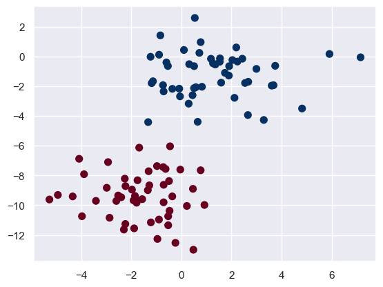

```python
from sklearn.datasets import make_blobs
X, y = make_blobs(100, 2, centers=2, random_state=2, cluster_std=1.5)
plt.scatter(X[:, 0],X[:, 1], c=y, s=50, cmap='RdBu')
```

```
[(-8.0, 8.0), (-15.0, 5.0)]
```

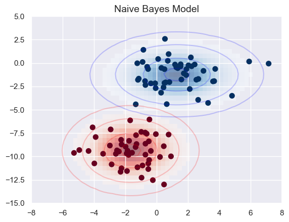

```python
from sklearn.datasets import make_blobs
X, y = make_blobs(100, 2, centers=2, random_state=2, cluster_std=1.5)

fig, ax = plt.subplots()
ax.scatter(X[:, 0], X[:, 1], c=y, s=50, cmap='RdBu')
ax.set_title('Naive Bayes Model', size=14)

xlim = (-8, 8)
ylim = (-15, 5)

xg = np.linspace(xlim[0], xlim[1], 60)
yg = np.linspace(ylim[0], ylim[1], 40)
xx, yy = np.meshgrid(xg, yg)
Xgrid = np.vstack([xx.ravel(), yy.ravel()]).T

for label, color in enumerate(['red', 'blue']):
    mask = (y == label)
    mu, std = X[mask].mean(0), X[mask].std(0)
    P = np.exp(-0.5 * (Xgrid - mu) ** 2 / std ** 2).prod(1)
    Pm = np.ma.masked_array(P, P < 0.03)
    ax.pcolorfast(xg, yg, Pm.reshape(xx.shape), alpha=0.5,
                  cmap=color.title() + 's')
    ax.contour(xx, yy, P.reshape(xx.shape),
               levels=[0.01, 0.1, 0.5, 0.9],
               colors=color, alpha=0.2)
ax.set(xlim=xlim, ylim=ylim)
```

```python
from sklearn.naive_bayes import GaussianNB
model = GaussianNB()
model.fit(X,y)
```

```
GaussianNB()
```

```python
rng = np.random.RandomState(0)
Xnew = [-6, -14] + [14, 18] * rng.rand(2000, 2)
ynew = model.predict(Xnew)
```

```
(-5.890554373486014,
 7.777566725032841,
 -13.775943665162341,
 3.3634536696825847)
```

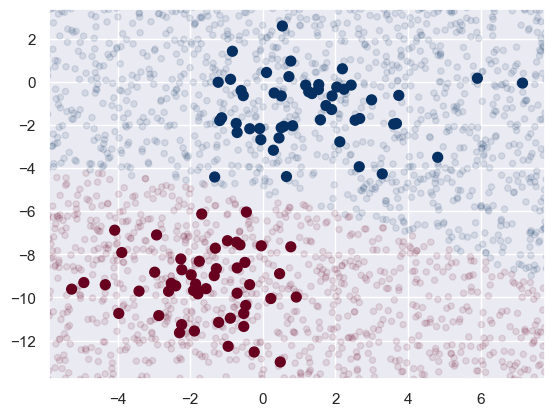

```python
plt.scatter(X[:, 0], X[:,1], c = y, s = 50, cmap = 'RdBu')
lim = plt.axis()
plt.scatter(Xnew[:, 0], Xnew[:, 1], c = ynew, s = 20, cmap = 'RdBu', alpha=0.1)
plt.axis(lim)
```

```python
yprob = model.predict_proba(Xnew)
yprob[-8:].round(2)
```

```
array([[0.89, 0.11],
       [1.  , 0.  ],
       [1.  , 0.  ],
       [1.  , 0.  ],
       [1.  , 0.  ],
       [1.  , 0.  ],
       [0.  , 1.  ],
       [0.15, 0.85]])
```

DATASET 1

```python
import pandas as pd
bahasa = pd.read_csv("dataset.csv")
bahasa["language"].unique()
```

```
array(['Estonian', 'Swedish', 'Thai', 'Tamil', 'Dutch', 'Japanese',
       'Turkish', 'Latin', 'Urdu', 'Indonesian', 'Portugese', 'French',
       'Chinese', 'Korean', 'Hindi', 'Spanish', 'Pushto', 'Persian',
       'Romanian', 'Russian', 'English', 'Arabic'], dtype=object)
```

```python
spam_shape = bahasa.shape
print("Data shape: {}".format(bahasa))
```

```
Data shape:                                                     Text  language
0      klement gottwaldi surnukeha palsameeriti ning ...  Estonian
1      sebes joseph pereira thomas  på eng the jesuit...   Swedish
2      ถนนเจริญกรุง อักษรโรมัน thanon charoen krung เ...      Thai
3      விசாகப்பட்டினம் தமிழ்ச்சங்கத்தை இந்துப் பத்திர...     Tamil
4      de spons behoort tot het geslacht haliclona en...     Dutch
...                                                  ...       ...
21995  hors du terrain les années  et  sont des année...    French
21996  ใน พศ  หลักจากที่เสด็จประพาสแหลมมลายู ชวา อินเ...      Thai
21997  con motivo de la celebración del septuagésimoq...   Spanish
21998  年月，當時還只有歲的她在美國出道，以mai-k名義推出首張英文《baby i like》，由...   Chinese
21999   aprilie sonda spațială messenger a nasa și-a ...  Romanian

[22000 rows x 2 columns]
```

```python
from sklearn.model_selection import train_test_split
train, test = train_test_split(bahasa, test_size=0.2)
```

```python
train = train.sample(frac=1).groupby('language').head(1000)
train.groupby('language')['Text'].count()
```

```
language
Arabic        785
Chinese       789
Dutch         808
English       776
Estonian      809
French        801
Hindi         817
Indonesian    792
Japanese      807
Korean        802
Latin         792
Persian       805
Portugese     811
Pushto        799
Romanian      815
Russian       812
Spanish       808
Swedish       778
Tamil         808
Thai          798
Turkish       793
Urdu          795
Name: Text, dtype: int64
```

```python
train.head(15)
```

|  | Text | language |
| --- | --- | --- |
| 13331 | san marino heeft zich nog nooit geplaatst voor... | Dutch |
| 16238 | دشرابوحُرمت لکه څرنګه چې په قرآنکریم کي په سخت... | Pushto |
| 4586 | kuramaa hertsogiriigi ajal valitses sabilet ka... | Estonian |
| 11589 | quocumque modo res se habet in hoc carmine mul... | Latin |
| 2573 | från dens tid finns namnen på ett antal höga t... | Swedish |
| 3085 | شهر هوراند در درجه و دقیقه طول شرقی و درجه و... | Persian |
| 8961 | இந்தக் கோவிலானது குருவாயூரில் இருந்து புன்னத்த... | Tamil |
| 21231 | çekimlerinin tamamı fasta gerçekleştirilen "gü... | Turkish |
| 14249 | исе́ть — посёлок до — посёлок городского типа... | Russian |
| 6274 | 實驗物理學擴展了工程學與科技，也被工程學與科技所擴展。涉及基礎研究的實驗者，在做實驗時，時常... | Chinese |
| 12824 | mitmesuguseid tavakonflikte ja nende omavaheli... | Estonian |
| 5957 | بنو عطية أولاد ميلاد التوائهية الصغائرية البر... | Arabic |
| 15020 | न्यायालय में नाथूराम गोडसे द्वारा दिये गये बया... | Hindi |
| 13468 | มีประชาธิปไตยกึ่งโดยตรงบางรูปแบบ ที่ผู้แทนจะบร... | Thai |
| 14709 | 年，奥尼尔在一份题为《与“金砖四国”一起梦想》的研究报告中预测，到年，世界经济格局将重新洗牌... | Chinese |

```python
from sklearn.feature_extraction.text import TfidfVectorizer
from sklearn.naive_bayes import MultinomialNB
from sklearn.pipeline import make_pipeline

model = make_pipeline(TfidfVectorizer(), MultinomialNB())
```

```python
model.fit(train['Text'], train['language'])
labels = model.predict(test['Text'])
```

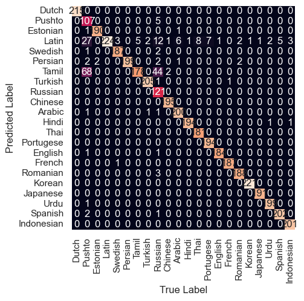

```python
from sklearn.metrics import confusion_matrix
mat = confusion_matrix(test['language'], labels)
sns.heatmap(mat.T, square=True, annot=True, fmt='d', cbar=False,
 xticklabels=train['language'].unique(), yticklabels=train['language'].unique())
plt.xlabel('True Label')
plt.ylabel('Predicted Label')
```

```python
def predict_category(s, train=train, model=model):
 pred = model.predict([s])
 return pred[0]
```

```python
predict_category('en navidad de poco después de que interpretó la canción en francés película papillon toi qui regard...')
```

```
'Spanish'
```

```python
predict_category('藤女の女性教師。歳。数学担当。風紀指導を担当しており、リコにとっては天敵。藤女とその伝統に強い誇りを抱いており、サヨの彼氏バレの際には厳しい態度を取る。その一方で体育祭の時に天ヶ崎が仕込んだ悪ふざけを...')
```

```
'Japanese'
```

```python
predict_category('dalam bahasa inggris istilah easter paskah menurut bede berasal dari bahasa saxon yaitu kata ēastre ...')
```

```
'Indonesian'
```

```python
test_acc = model.score(test['Text'], test['language'])
print(f'Test Accuracy: {test_acc:.3f}')
```

```
Test Accuracy: 0.946
```

SVM

```python
%matplotlib inline
import numpy as np
import matplotlib.pyplot as plt
from scipy import stats

import seaborn as sns; sns.set()
```

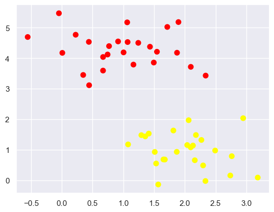

```python
from sklearn.datasets import make_blobs
X, y = make_blobs(n_samples=50, centers=2,
 random_state=0, cluster_std=0.60)
plt.scatter(X[:, 0], X[:, 1], c=y, s=50, cmap='autumn');
```

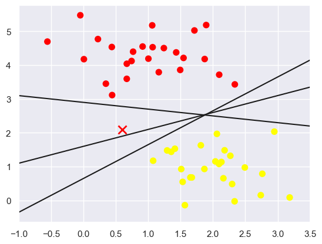

```python
xfit = np.linspace(-1, 3.5)
plt.scatter(X[:, 0], X[:, 1], c=y, s=50, cmap='autumn')
plt.plot([0.6], [2.1], 'x', color='red', markeredgewidth=2, markersize=10)
for m, b in [(1, 0.65), (0.5, 1.6), (-0.2, 2.9)]:
 plt.plot(xfit, m * xfit + b, '-k')

plt.xlim(-1, 3.5);
```

```
(-1.0, 3.5)
```

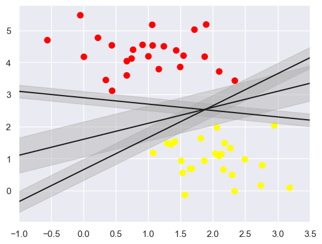

```python
xfit = np.linspace(-1, 3.5)
plt.scatter(X[:, 0], X[:, 1], c=y, s=50, cmap='autumn')
for m, b, d in [(1, 0.65, 0.33), (0.5, 1.6, 0.55), (-0.2, 2.9, 0.2)]:
 yfit = m * xfit + b
 plt.plot(xfit, yfit, '-k')
 plt.fill_between(xfit, yfit-d, yfit+d, edgecolor='none', color='#AAAAAA', alpha=0.4)

plt.xlim(-1, 3.5)
```

```python
from sklearn.svm import SVC
model = SVC(kernel='linear', C=1E10)
model.fit(X, y)
```

```
SVC(C=10000000000.0, kernel='linear')
```

```python
def plot_svc_decision_function(model, ax=None, plot_support=True):
    """Plot the decision function for a 2D SVC"""
    if ax is None:
        ax = plt.gca()
        xlim = ax.get_xlim()
        ylim = ax.get_ylim()

        #create grid to evaluate model
        x = np.linspace(xlim[0], xlim[1], 30)
        y = np.linspace(ylim[0], ylim[1], 30)
        Y, X = np.meshgrid(y, x)
        xy = np.vstack([X.ravel(), Y.ravel()]).T
        P = model.decision_function(xy).reshape(X.shape)

        #plot decision boundary and margins
        ax.contour(X, Y, P, colors='k',
                   levels=[-1,0,1], alpha=0.5,
                   linestyles=['--', '-', '--'])

        #plot support vectors
        if plot_support:
            ax.scatter(model.support_vectors_[:, 0],
                       model.support_vectors_[:, 1],
                       s=300, linewidth=1, facecolors='none');
        ax.set_xlim(xlim)
        ax.set_ylim(ylim)
```

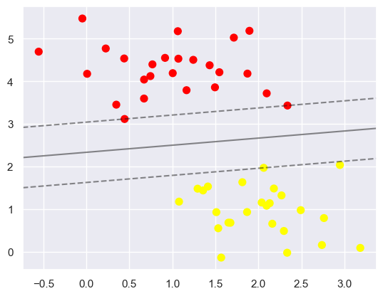

```python
plt.scatter(X[:, 0], X[:, 1], c=y, s=50, cmap='autumn')
plot_svc_decision_function(model);
```

```python
model.support_vectors_
```

```
array([[0.44359863, 3.11530945],
       [2.33812285, 3.43116792],
       [2.06156753, 1.96918596]])
```

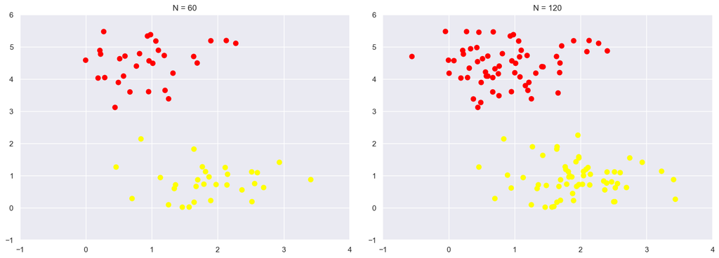

```python
def plot_svm(N=10, ax=None):
    X, y = make_blobs(n_samples=200, centers=2,
                      random_state=0, cluster_std=0.60)

    X = X[:N]
    y = y[:N]
    model = SVC(kernel='linear', C=1E10)
    model.fit(X, y)

    ax = ax or plt.gca()
    ax.scatter(X[:, 0], X[:, 1], c=y, s=50, cmap='autumn')
    ax.set_xlim(-1, 4)
    ax.set_ylim(-1, 6)
    plot_svc_decision_function(model, ax)

fig, ax = plt.subplots(1, 2, figsize=(16, 6))
fig.subplots_adjust(left=0.0625, right=0.95, wspace=0.1)
for axi, N in zip(ax, [60, 120]):
    plot_svm(N, axi)
    axi.set_title('N = {0}'.format(N))
```

```python
from ipywidgets import interact, fixed
interact(plot_svm, N=[10, 200], ax=fixed(None));
```

```
interactive(children=(Dropdown(description='N', options=(10, 200), value=10), Output()), _dom_classes=('widget…
```

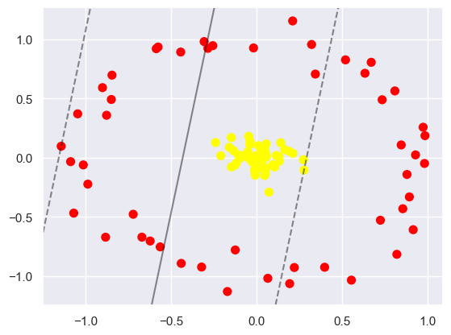

```python
from sklearn.datasets import make_circles

X, y = make_circles(100, factor=.1, noise=.1)
clf = SVC(kernel='linear').fit(X, y)

plt.scatter(X[:, 0], X[:, 1], c=y, s=50, cmap='autumn')
plot_svc_decision_function(clf, plot_support=False);
```

```python
r = np.exp(-(X ** 2).sum(1))
```

```python
from mpl_toolkits import mplot3d

def plot_3D(elev=30, azim=30, X=X, y=y):
    ax = plt.subplot(projection='3d')
    ax.scatter3D(X[:, 0], X[:, 1], r, c=y, s=50, cmap='autumn')
    ax.view_init(elev=elev, azim=azim)
    ax.set_xlabel('x')
    ax.set_ylabel('y')
    ax.set_zlabel('r')

interact(plot_3D, elev=[-90, 90], azip=(-180, 180),
         X=fixed(X), y=fixed(y));
```

```
interactive(children=(Dropdown(description='elev', options=(-90, 90), value=-90), IntSlider(value=30, descript…
```

```python
clf = SVC(kernel='rbf', C=1E6)
clf.fit(X, y)
```

```
SVC(C=1000000.0)
```

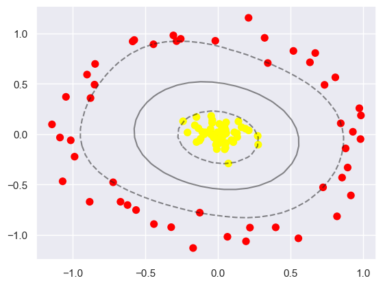

```python
plt.scatter(X[:, 0], X[:, 1], c=y, s=50, cmap='autumn')
plot_svc_decision_function(clf)
plt.scatter(clf.support_vectors_[:, 0], clf.support_vectors_[:, 1],
            s=300, lw=1, facecolors='none');
```

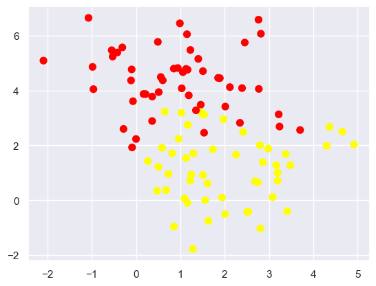

```python
X, y = make_blobs(n_samples=100, centers=2,
                  random_state=0, cluster_std=1.2)
plt.scatter(X[:, 0], X[:, 1], c=y, s=50, cmap='autumn');
```

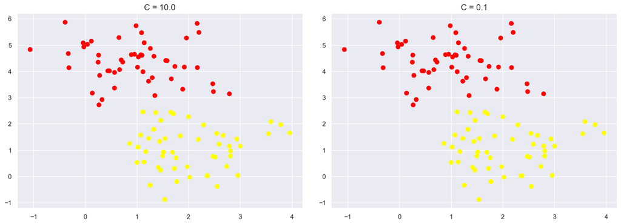

```python
X, y = make_blobs(n_samples=100, centers=2,
                  random_state=0, cluster_std=0.8)

fig, ax = plt.subplots(1, 2, figsize=(16, 6))
fig.subplots_adjust(left=0.0625, right=0.95, wspace=0.1)

for axi, C in zip(ax, [10.0, 0.1]):
    model = SVC(kernel='linear', C=C).fit(X, y)
    axi.scatter(X[:, 0], X[:, 1], c=y, s=50, cmap='autumn')
    plot_svc_decision_function(model, axi)
    axi.scatter(model.support_vectors_[:, 0],
                model.support_vectors_[:, 1],
                s=300, lw=1, facecolors='none');
    axi.set_title('C = {0:.1f}'.format(C), size=14)
```

```python
gambar = pd.read_csv("mnist_test.csv")
print(gambar.shape)
```

```
(12000, 785)
```

```python
print(gambar.index)
```

```
RangeIndex(start=0, stop=12000, step=1)
```

```python
num_columns = gambar.shape[1]
print("Jumlah kolom dalam dataset: ", num_columns)
```

```
Jumlah kolom dalam dataset:  785
```

```python
print(gambar.head())
```

```
   label  pixel0  pixel1  pixel2  pixel3  pixel4  pixel5  pixel6  pixel7  \
0      2       0       0       0       0       0       0       0       0
1      3       0       0       0       0       0       0       0       0
2      0       0       0       0       0       0       0       0       0
3      3       0       0       0       0       0       0       0       0
4      8       0       0       0       0       0       0       0       0

   pixel8  ...  pixel774  pixel775  pixel776  pixel777  pixel778  pixel779  \
0       0  ...         0         0         0         0         0         0
1       0  ...         0         0         0         0         0         0
2       0  ...         0         0         0         0         0         0
3       0  ...         0         0         0         0         0         0
4       0  ...         0         0         0         0         0         0

   pixel780  pixel781  pixel782  pixel783
0         0         0         0         0
1         0         0         0         0
2         0         0         0         0
3         0         0         0         0
4         0         0         0         0

[5 rows x 785 columns]
```

```python
print(gambar.info())
```

```
<class 'pandas.core.frame.DataFrame'>
RangeIndex: 12000 entries, 0 to 11999
Columns: 785 entries, label to pixel783
dtypes: int64(785)
memory usage: 71.9 MB
None
```

```python
gambar['label'].replace({0:'0',
                          1:'1',
                          2:'2',
                          3:'3',
                          4:'4',
                          5:'5',
                          6:'6',
                          7:'7',
                          8:'8',
                          9:'9'}, inplace = True)

print(gambar['label'].unique())
```

```
['2' '3' '0' '8' '4' '7' '1' '5' '9' '6']
```

```python
X = gambar.drop(columns=['label'])
y = gambar['label']

print(X.shape)
print(np.sqrt(784))
```

```
(12000, 784)
28.0
```

```python
print(gambar)
```

```
      label  pixel0  pixel1  pixel2  pixel3  pixel4  pixel5  pixel6  pixel7  \
0         2       0       0       0       0       0       0       0       0
1         3       0       0       0       0       0       0       0       0
2         0       0       0       0       0       0       0       0       0
3         3       0       0       0       0       0       0       0       0
4         8       0       0       0       0       0       0       0       0
...     ...     ...     ...     ...     ...     ...     ...     ...     ...
11995     9       0       0       0       0       0       0       0       0
11996     6       0       0       0       0       0       0       0       0
11997     4       0       0       0       0       0       0       0       0
11998     0       0       0       0       0       0       0       0       0
11999     1       0       0       0       0       0       0       0       0

       pixel8  ...  pixel774  pixel775  pixel776  pixel777  pixel778  \
0           0  ...         0         0         0         0         0
```

[output cut: 25 more lines]

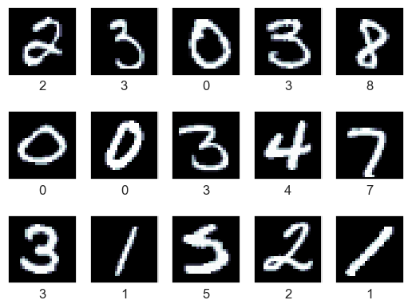

```python
fig, ax = plt.subplots(3, 5)
for i, axi in enumerate(ax.flat):
    axi.imshow(X.iloc[i].values.reshape(28, 28), cmap='bone')
    axi.set(xticks=[], yticks=[],
            xlabel=y.iloc[i])
```

```python
from sklearn.svm import SVC
from sklearn.decomposition import PCA as RandomizedPCA
from sklearn.pipeline import make_pipeline

pca = RandomizedPCA(n_components=150, whiten=True, svd_solver='randomized', random_state=42)
svc = SVC(kernel='rbf', class_weight='balanced')
model = make_pipeline(pca, svc)
X_train, X_test, y_train, y_test = train_test_split(X, y, random_state=42)
```

```python
from sklearn.model_selection import GridSearchCV
param_grid = {'svc__C': [1, 5, 10, 50],
              'svc__gamma': [0.0001, 0.0005, 0.001, 0.005]}
grid = GridSearchCV(model, param_grid, cv=3, n_jobs=-1)
%time grid.fit(X_train, y_train)
print(grid.best_params_)
```

[output not shown]

```python
model = grid.best_estimator_
yfit = model.predict(X_test)
```

```python
fig, ax = plt.subplots(5, 6)
for i, axi in enumerate(ax.flat):
    axi.imshow(X_test.iloc[i].values.reshape(28, 28), cmap='bone')
    axi.set(xticks=[], yticks=[])
    axi.set_ylabel(yfit[i].split()[-1],
                   color='black' if yfit[i] == y_test.iloc[i] else 'red')
fig.suptitle('Predicted Names; Incorrect Labels in Red', size=14);
```

[output not shown]

```python
from sklearn.metrics import classification_report
print(classification_report(y_test, yfit, target_names = y.unique()))
```

[output not shown]

```python
from sklearn.metrics import confusion_matrix
mat = confusion_matrix(y_test, yfit)
sns.heatmap(mat.T, square=True, annot=True, fmt='d', cbar=False,
            xticklabels=y.unique(), yticklabels=y.unique())
plt.xlabel('true label')
plt.ylabel('predicted label');
```

[output not shown]

### Kesimpulan

[output not shown]

```python
# Footer
myDate = datetime.datetime.now()
print("I certify that this is my own work.")
print("Signed by:")
print("Name: \t\t{}".format(myName))
print("NIM: \t\t{}".format(myNIM))
print("Time-stamp:\t{}".format(myDate))
```

[output not shown]

### Save the notebook, then convert the notebook to html (by running the next code).

```python
!jupyter nbconvert --to html "./IF540L_Kelas_EL_laporan_M07_00000060236_Nisaul Fadhilah.ipynb" --output-dir="./"
```